# Научно-Исследовательская Работа

## I

В качестве датасета выберу набор данных о продаже автомобилей с пробегом с сервиса Craigslist:

https://kaggle.com/datasets/austinreese/craigslist-carstrucks-data

Датасет состоит из одного файла `vehicles.csv` со следующими полями:

- *id* - entry ID
- *url* - listing URL
- *region* - craigslist region
- *region_url* - region URL
- *price* - entry price
- *year* - entry year
- *manufacturer* - manufacturer of vehicle
- *model* - mode of vehicle
- *condition* - condition of vehicle
- *cylinders* - number of cylinders
- *fuel* - fuel type
- *odometer* - miles traveled by vehicle
- *title_status* - title status of vehicle
- *transmission* - transmission of vehicle
- *VIN* - vehicle identification number
- *drive* - type of drive
- *size* - size of vehicle
- *type* - generic type of vehicle
- *paint_color* - color of vehicle
- *image_url* - image URL
- *description* - listed description of vehicle
- *county* - empty column (left in dataset)
- *state* - state of listing
- *lat* - latitude of listing
- *long* - longitude of listing
- *posting_date* - posting date

Будем решать задачу **регрессии** - будем предсказывать стоимость автомобиля (поле `price`) по его характеристикам

## Импорт библиотек

```python
import pandas as pd
import numpy as np
import matplotlib.pyplot as plt
import seaborn as sns
from sklearn.preprocessing import LabelEncoder, MinMaxScaler
from sklearn.linear_model import LinearRegression
from sklearn.neighbors import KNeighborsRegressor
from sklearn.svm import SVR
from sklearn.tree import DecisionTreeRegressor
from sklearn.ensemble import RandomForestRegressor, GradientBoostingRegressor
from sklearn.metrics import mean_absolute_error, mean_squared_error, r2_score
```

## Загрузка данных

```python
df = pd.read_csv('vehicles.csv')
```

## Проведение разведочного анализа данных

```python
df.head()
```

|  | id | url | region | region_url | price | year | manufacturer | model | condition | cylinders | ... | size | type | paint_color | image_url | description | county | state | lat | long | posting_date |
| --- | --- | --- | --- | --- | --- | --- | --- | --- | --- | --- | --- | --- | --- | --- | --- | --- | --- | --- | --- | --- | --- |
| 0 | 7222695916 | https://prescott.craigslist.org/cto/d/prescott... | prescott | https://prescott.craigslist.org | 6000 | NaN | NaN | NaN | NaN | NaN | ... | NaN | NaN | NaN | NaN | NaN | NaN | az | NaN | NaN | NaN |
| 1 | 7218891961 | https://fayar.craigslist.org/ctd/d/bentonville... | fayetteville | https://fayar.craigslist.org | 11900 | NaN | NaN | NaN | NaN | NaN | ... | NaN | NaN | NaN | NaN | NaN | NaN | ar | NaN | NaN | NaN |
| 2 | 7221797935 | https://keys.craigslist.org/cto/d/summerland-k... | florida keys | https://keys.craigslist.org | 21000 | NaN | NaN | NaN | NaN | NaN | ... | NaN | NaN | NaN | NaN | NaN | NaN | fl | NaN | NaN | NaN |
| 3 | 7222270760 | https://worcester.craigslist.org/cto/d/west-br... | worcester / central MA | https://worcester.craigslist.org | 1500 | NaN | NaN | NaN | NaN | NaN | ... | NaN | NaN | NaN | NaN | NaN | NaN | ma | NaN | NaN | NaN |
| 4 | 7210384030 | https://greensboro.craigslist.org/cto/d/trinit... | greensboro | https://greensboro.craigslist.org | 4900 | NaN | NaN | NaN | NaN | NaN | ... | NaN | NaN | NaN | NaN | NaN | NaN | nc | NaN | NaN | NaN |

5 rows × 26 columns

```python
df.shape
```

```
(426880, 26)
```

```python
df.columns
```

```
Index(['id', 'url', 'region', 'region_url', 'price', 'year', 'manufacturer',
       'model', 'condition', 'cylinders', 'fuel', 'odometer', 'title_status',
       'transmission', 'VIN', 'drive', 'size', 'type', 'paint_color',
       'image_url', 'description', 'county', 'state', 'lat', 'long',
       'posting_date'],
      dtype='object')
```

```python
df.dtypes
```

```
id                int64
url              object
region           object
region_url       object
price             int64
year            float64
manufacturer     object
model            object
condition        object
cylinders        object
fuel             object
odometer        float64
title_status     object
transmission     object
VIN              object
drive            object
size             object
type             object
paint_color      object
image_url        object
description      object
county          float64
state            object
lat             float64
long            float64
posting_date     object
dtype: object
```

Так как датасет очень большой (более 426000 строк, размер файла $\approx$ 1.5 GB), искусственно сократим его до 7500 записей.

```python
df = df.sample(n=7500, random_state=39)
```

## Определение используемых колонок

```python
df.drop(columns=['id', 'url', 'region_url', 'title_status', 'VIN', 'image_url', 'description', 'county', 'lat', 'long'], inplace=True)
```

## Удаление дупликатов

```python
df.drop_duplicates(inplace=True)
```

## Обработка пропусков

Проверим датасет на наличие пустых значений:

```python
df.isnull().sum()
```

```
region             0
price              0
year              27
manufacturer     301
model             81
condition       3068
cylinders       3146
fuel              55
odometer          73
transmission      40
drive           2300
size            5363
type            1569
paint_color     2192
state              0
posting_date       3
dtype: int64
```

Так как имеем достаточно много пропусков, просто удалить их не получится - мы сотрём большую часть датасета.  
Произведём заполнение пропусков:

```python
for col in df.columns:
    most_frequent = df[col].dropna().mode()[0]
    df[col].fillna(most_frequent, inplace=True)
```

```python
df.isnull().sum()
```

```
region          0
price           0
year            0
manufacturer    0
model           0
condition       0
cylinders       0
fuel            0
odometer        0
transmission    0
drive           0
size            0
type            0
paint_color     0
state           0
posting_date    0
dtype: int64
```

```python
df.head()
```

|  | region | price | year | manufacturer | model | condition | cylinders | fuel | odometer | transmission | drive | size | type | paint_color | state | posting_date |
| --- | --- | --- | --- | --- | --- | --- | --- | --- | --- | --- | --- | --- | --- | --- | --- | --- |
| 72041 | boulder | 14999 | 2015.0 | subaru | forester 2.5i | good | 4 cylinders | gas | 82928.0 | manual | 4wd | full-size | sedan | white | co | 2021-04-24T13:44:01-0600 |
| 133139 | boise | 195 | 2013.0 | subaru | impreza wagon | excellent | 4 cylinders | gas | 106441.0 | automatic | fwd | full-size | wagon | blue | id | 2021-04-26T14:57:27-0600 |
| 328128 | altoona-johnstown | 4500 | 1998.0 | ram | 1500 slt laramie | good | 6 cylinders | gas | 201000.0 | automatic | 4wd | full-size | sedan | white | pa | 2021-04-12T13:44:26-0400 |
| 320183 | medford-ashland | 2499 | 1999.0 | nissan | altima | excellent | 4 cylinders | gas | 237000.0 | manual | fwd | compact | sedan | white | or | 2021-04-16T14:47:22-0700 |
| 80531 | fort collins / north CO | 14990 | 2015.0 | nissan | leaf sv hatchback 4d | good | 6 cylinders | electric | 26816.0 | other | fwd | full-size | hatchback | white | co | 2021-04-08T07:15:17-0600 |

Пропуски были успещно заполнены.

## Обработка имеющихся колонок

Заменим колонку `posting_date` на более удобную числовую колонку `posted_days_ago`.

```python
df['posting_date'] = pd.to_datetime(df['posting_date'])
df['posting_date'] = df['posting_date'].dt.tz_localize(None)
```

```python
current_date = pd.Timestamp('now').normalize()
df['posted_days_ago'] = (current_date - df['posting_date']).dt.days
df.drop(columns='posting_date', inplace=True)
```

```python
df.head()
```

[output not shown]

Успешно заменили колонку с датой. Теперь мы сможем использовать её для анализа данных и обучения моделей.

## Кодирование категориальных признаков

```python
le = LabelEncoder()

for col in df.columns:
    if str(df[col].dtype) in ['float64', 'int64']:
        continue
    df[col] = le.fit_transform(df[col])
df.head()
```

|  | region | price | year | manufacturer | model | condition | cylinders | fuel | odometer | transmission | drive | size | type | paint_color | state | posted_days_ago |
| --- | --- | --- | --- | --- | --- | --- | --- | --- | --- | --- | --- | --- | --- | --- | --- | --- |
| 72041 | 35 | 14999 | 2015.0 | 35 | 1337 | 2 | 3 | 2 | 82928.0 | 1 | 0 | 1 | 9 | 10 | 5 | 1136 |
| 133139 | 32 | 195 | 2013.0 | 35 | 1562 | 0 | 3 | 2 | 106441.0 | 0 | 1 | 1 | 12 | 1 | 13 | 1134 |
| 328128 | 5 | 4500 | 1998.0 | 32 | 51 | 2 | 5 | 2 | 201000.0 | 0 | 0 | 1 | 9 | 10 | 38 | 1148 |
| 320183 | 206 | 2499 | 1999.0 | 29 | 499 | 0 | 3 | 2 | 237000.0 | 1 | 1 | 0 | 9 | 10 | 37 | 1144 |
| 80531 | 111 | 14990 | 2015.0 | 29 | 1632 | 2 | 5 | 1 | 26816.0 | 2 | 1 | 1 | 4 | 10 | 5 | 1152 |

## Построение графиков

```python
cat_cols = ['region', 'manufacturer', 'condition', 'cylinders', 'fuel', 'transmission', 'drive', 'size', 'type', 'paint_color', 'state']
```

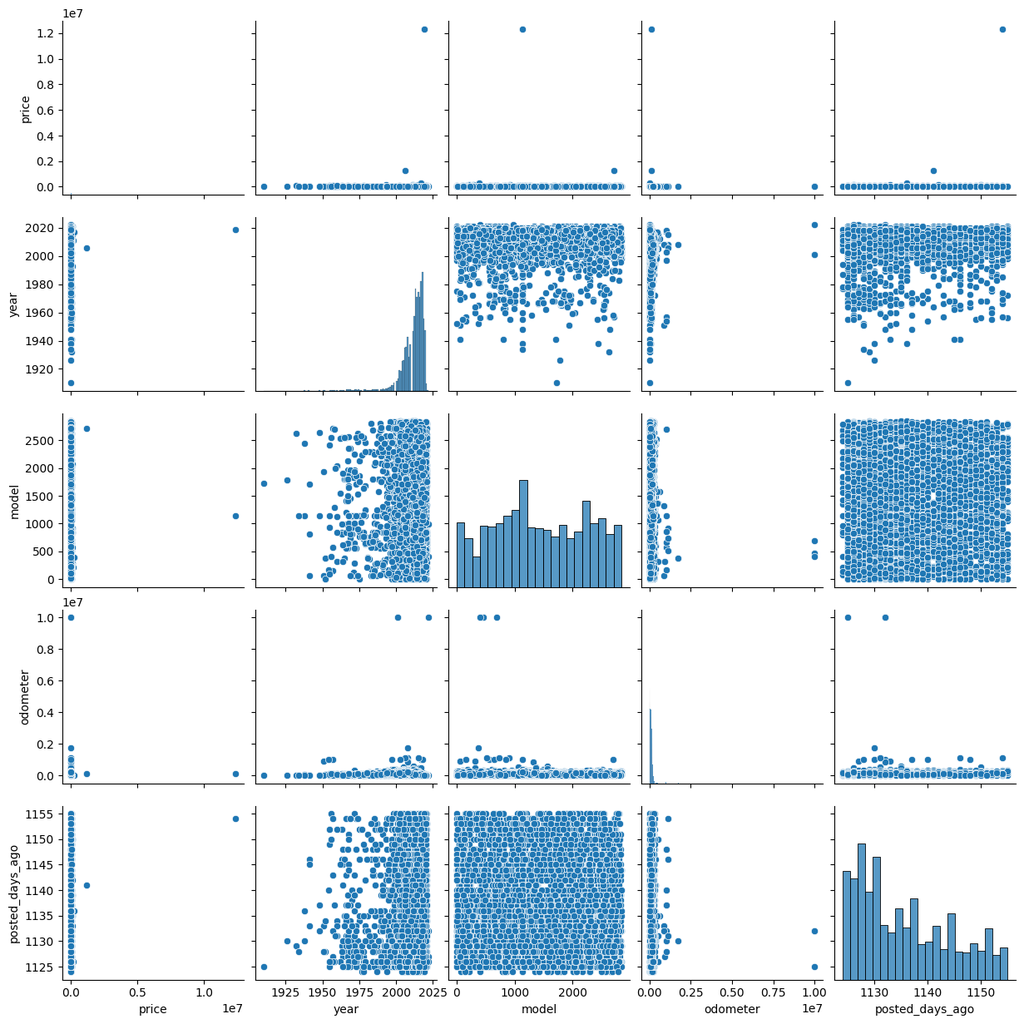

```python
sns.pairplot(df.drop(columns=cat_cols))
```

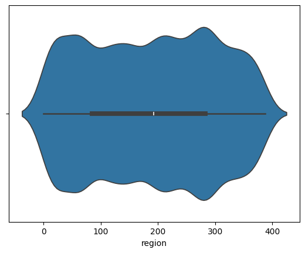

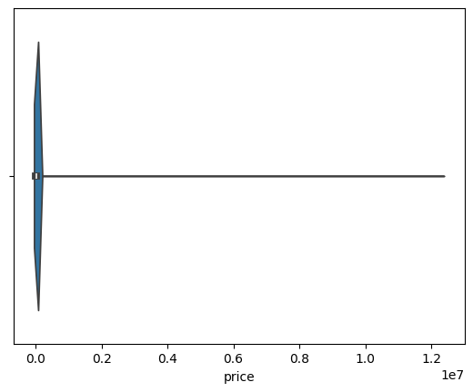

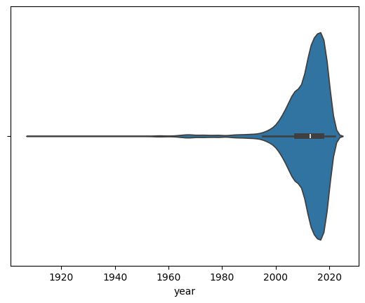

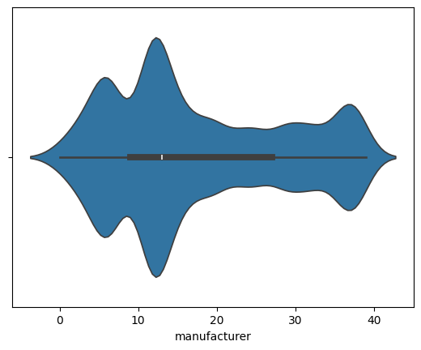

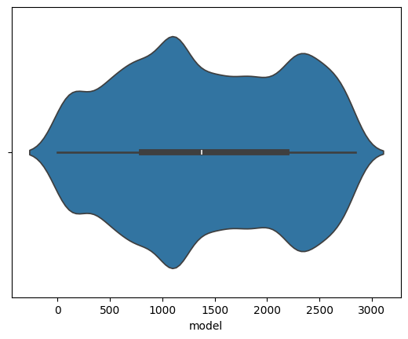

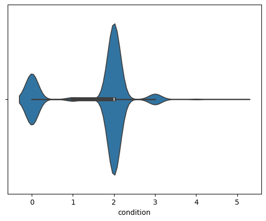

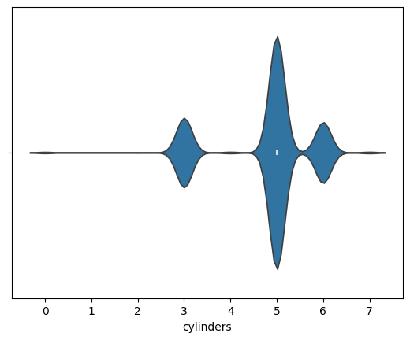

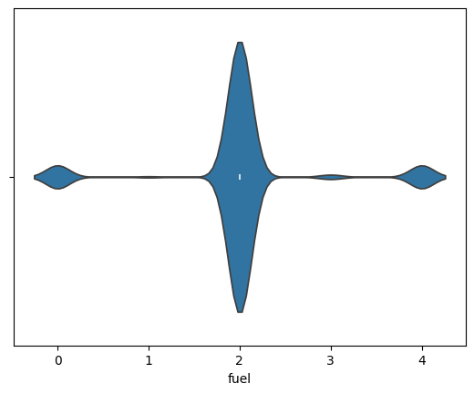

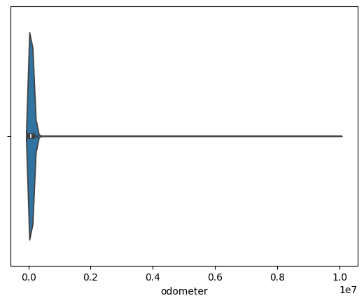

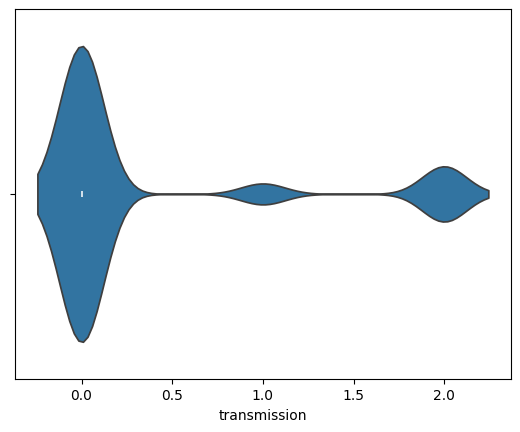

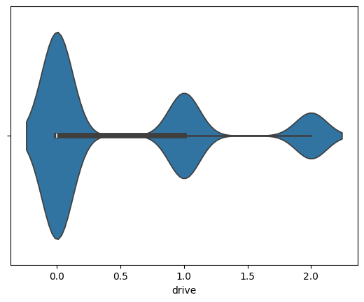

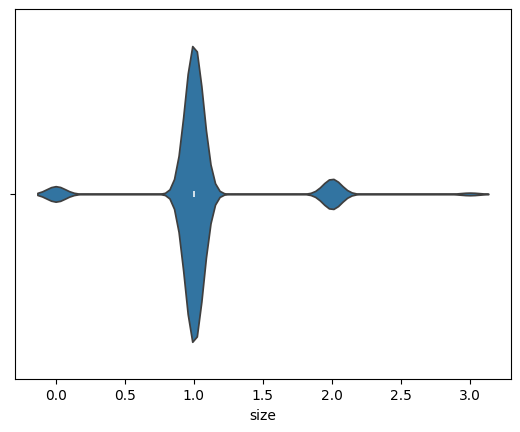

[4 more figures not shown]

```python
for col in df.columns:
    if str(df[col].dtype) not in ['int64', 'float64']:
        continue
    sns.violinplot(x=df[col])
    plt.show()
```

## Масштабирование данных

```
['year', 'model', 'odometer', 'posted_days_ago']
```

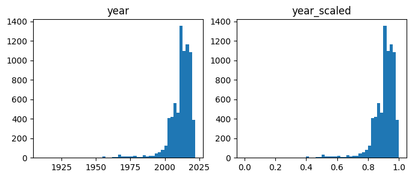

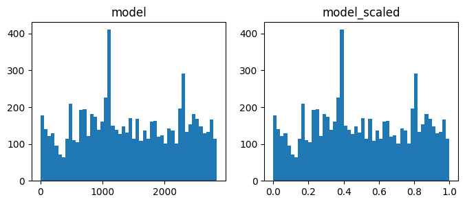

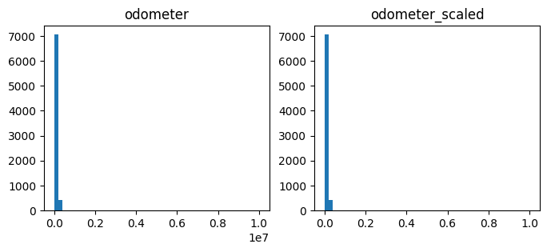

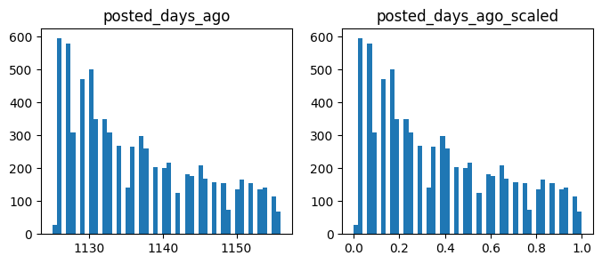

```python
df_scaler = MinMaxScaler()

cols_to_scale = list(df.columns)
cols_to_scale.remove('price')
for x in cat_cols:
    cols_to_scale.remove(x)

print(cols_to_scale)

for col in cols_to_scale:
    if str(df[col].dtype) not in ['int64', 'float64']:
        continue

    fig, ax = plt.subplots(1, 2, figsize=(8,3))
    ax[0].hist(df[col], 50)
    ax[0].title.set_text(col)

    df[[col]] = df_scaler.fit_transform(df[[col]])

    ax[1].hist(df[col], 50)
    ax[1].title.set_text(col + '_scaled')
    plt.show()
```

Промасштабировали все признаки, кроме категориальных и целевого.

Как видим, распределение данных осталось прежним.

```python
df.head()
```

|  | region | price | year | manufacturer | model | condition | cylinders | fuel | odometer | transmission | drive | size | type | paint_color | state | posted_days_ago |
| --- | --- | --- | --- | --- | --- | --- | --- | --- | --- | --- | --- | --- | --- | --- | --- | --- |
| 72041 | 35 | 14999 | 0.937500 | 35 | 0.470775 | 2 | 3 | 2 | 0.008293 | 1 | 0 | 1 | 9 | 10 | 5 | 0.354839 |
| 133139 | 32 | 195 | 0.919643 | 35 | 0.550000 | 0 | 3 | 2 | 0.010644 | 0 | 1 | 1 | 12 | 1 | 13 | 0.290323 |
| 328128 | 5 | 4500 | 0.785714 | 32 | 0.017958 | 2 | 5 | 2 | 0.020100 | 0 | 0 | 1 | 9 | 10 | 38 | 0.741935 |
| 320183 | 206 | 2499 | 0.794643 | 29 | 0.175704 | 0 | 3 | 2 | 0.023700 | 1 | 1 | 0 | 9 | 10 | 37 | 0.612903 |
| 80531 | 111 | 14990 | 0.937500 | 29 | 0.574648 | 2 | 5 | 1 | 0.002682 | 2 | 1 | 1 | 4 | 10 | 5 | 0.870968 |

## Корреляционный анализ данных

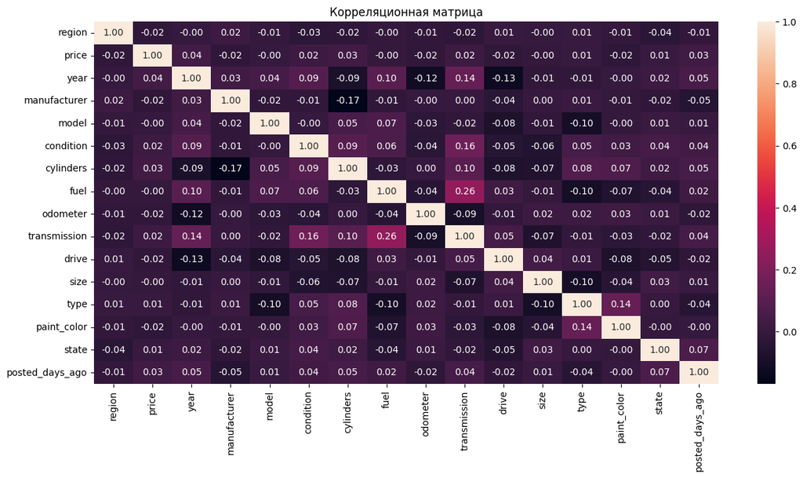

```python
fig, ax = plt.subplots(figsize=(15,7))
sns.heatmap(df.corr(), annot=True, fmt='.2f')
ax.set_title('Корреляционная матрица')
plt.show()
```

Как видим по матрице корреляции, у целевого признака нет сильных корреляций с другими, в основном потому что большинство колонок в датасете - категориальные.

Так же видим, что остальные признаки, которые будут учавтвствовать в обучении ML-моделей, нет сильных корреляций друг с другом (максимальная корреляция - `0.26`), поэтому можно не удалять колонки.

## Выбор метрик для последующей оценки качества моделей

В качестве метрик будем использовать:

- MAE
- MSE
- R2

Метрика R2 показывает относительное отклонение предсказанных значений от реальных, в то время как MAE и MSE показывают ошибку в единицах измерения целевого признака.

Так как метрика R2 в одиночку достаточно неточная, MAE и MSE гармонично её дополняют и в совокупности дают полную картину о точности модели.

```python
class MetricLogger:

    def __init__(self):
        self.df = pd.DataFrame(
            {'metric': pd.Series([], dtype='str'),
            'alg': pd.Series([], dtype='str'),
            'value': pd.Series([], dtype='float')})

    def add(self, metric, alg, value):
        """
        Добавление значения
        """
        # Удаление значения если оно уже было ранее добавлено
        self.df.drop(self.df[(self.df['metric']==metric)&(self.df['alg']==alg)].index, inplace = True)
        # Добавление нового значения
        temp = pd.DataFrame([{'metric':metric, 'alg':alg, 'value':value}])
        self.df = pd.concat([self.df, temp], ignore_index=True)
    def get_data_for_metric(self, metric, ascending=True):
        """
        Формирование данных с фильтром по метрике
        """
        temp_data = self.df[self.df['metric']==metric]
        temp_data_2 = temp_data.sort_values(by='value', ascending=ascending)
        return temp_data_2['alg'].values, temp_data_2['value'].values
    def plot(self, str_header, metric, ascending=True, figsize=(5, 5)):
        """
        Вывод графика
        """
        array_labels, array_metric = self.get_data_for_metric(metric, ascending)
        fig, ax1 = plt.subplots(figsize=figsize)
        pos = np.arange(len(array_metric))
        metric_max = np.max(array_metric)
        metric_min = np.min(array_metric)
        metric_min_max_diff = metric_max - metric_min
        array_metric_normalized = np.copy(array_metric)
        for i in range(len(array_metric)):
            array_metric_normalized[i] = array_metric[i] * 1000.0
        rects = ax1.barh(pos, array_metric_normalized,
                         align='center',
                         height=0.5,
                         tick_label=array_labels)
        ax1.set_title(str_header)

        for bar,value in zip(rects, array_metric):
            plt.text(bar.get_width()/2, bar.get_y() + bar.get_height() / 2, f'{value:.5f}',
                va='center', ha='left')
            # plt.text(0.5, a-0.05, str(round(b,3)), color='white')
        plt.show()
metric_logger = MetricLogger()
```

## Выбор наиболее подходящих моделей для решения задачи классификации или регрессии

```python
models = {
    'Linear Regression   ': LinearRegression(),
    'K Nearest Neighbors ': KNeighborsRegressor(),
    'Support Vector      ': SVR(),
    'Decision Tree       ': DecisionTreeRegressor(),
    'Random Forest       ': RandomForestRegressor(),
    'Gradient Boosting   ': GradientBoostingRegressor()
}
```

## Формирования обучающей и тестовой выборок на основе исходного набора данных

```python
from sklearn.model_selection import train_test_split

x_df = df.drop(columns='price')
y_df = df['price']

x_train, x_test, y_train, y_test = train_test_split(x_df, y_df, test_size=0.3, random_state=73)

print(x_train.shape, y_train.shape)
print(x_test.shape, y_test.shape)
```

```
(5250, 15) (5250,)
(2250, 15) (2250,)
```

## Построение базового решения для выбранных моделей без подбора гиперпараметров

```python
def train_model(model_name, model, metric_logger):
    model.fit(x_train, y_train)
    y_predict = model.predict(x_test)

    mae = mean_absolute_error(y_test, y_predict)
    mse = mean_squared_error(y_test, y_predict)
    r2 = r2_score(y_test, y_predict)

    metric_logger.add('MAE', model_name, mae)
    metric_logger.add('MSE', model_name, mse)
    metric_logger.add('R2', model_name, r2)

    print('{} \t MAE={}, MSE={}, R2={}'.format(
        model_name, round(mae, 3), round(mse, 3), round(r2, 3)))
```

```python
for model_name, model in models.items():
    train_model(model_name, model, metric_logger)
```

```
Linear Regression    	 MAE=13089.812, MSE=328284719.073, R2=-0.186
K Nearest Neighbors  	 MAE=17152.471, MSE=11236138013.313, R2=-39.583
Support Vector       	 MAE=11804.566, MSE=289731793.001, R2=-0.046
Decision Tree        	 MAE=9737.822, MSE=913972393.621, R2=-2.301
Random Forest        	 MAE=9928.328, MSE=4082709949.808, R2=-13.746
Gradient Boosting    	 MAE=8007.121, MSE=206448803.469, R2=0.254
```

## Подбор гиперпараметров

```python
tuned_params_knn = [{'n_neighbors': np.array(range(1,2100,100))}]
tuned_params_svr = [{'C': np.array([1.0, 2.0, 3.0, 4.0, 5.0])}]
tuned_params_dt = [{'max_depth': np.array(range(1, 110, 10))}]
tuned_params_rf = [{'n_estimators': np.array(range(1, 500, 100))}]
tuned_params_gb = [{'n_estimators': np.array(range(1, 1100, 100))}]
```

```python
%%time

from sklearn.model_selection import GridSearchCV

knn_gs = GridSearchCV(KNeighborsRegressor(), tuned_params_knn, cv=5, scoring='neg_mean_squared_error', verbose=1)
knn_gs.fit(x_train, y_train)
```

```
Fitting 5 folds for each of 21 candidates, totalling 105 fits
CPU times: user 15.6 s, sys: 33.7 ms, total: 15.7 s
Wall time: 15.7 s
```

```
GridSearchCV(cv=5, estimator=KNeighborsRegressor(),
             param_grid=[{'n_neighbors': array([   1,  101,  201,  301,  401,  501,  601,  701,  801,  901, 1001,
       1101, 1201, 1301, 1401, 1501, 1601, 1701, 1801, 1901, 2001])}],
             scoring='neg_mean_squared_error', verbose=1)
```

```python
%%time

svr_gs = GridSearchCV(SVR(), tuned_params_svr, cv=5, scoring='neg_mean_squared_error', verbose=1)
svr_gs.fit(x_train, y_train)
```

```
Fitting 5 folds for each of 5 candidates, totalling 25 fits
CPU times: user 22.9 s, sys: 4.89 ms, total: 22.9 s
Wall time: 23 s
```

```
GridSearchCV(cv=5, estimator=SVR(),
             param_grid=[{'C': array([1., 2., 3., 4., 5.])}],
             scoring='neg_mean_squared_error', verbose=1)
```

```python
%%time

dt_gs = GridSearchCV(DecisionTreeRegressor(), tuned_params_dt, cv=5, scoring='neg_mean_squared_error', verbose=1)
dt_gs.fit(x_train, y_train)
```

```
Fitting 5 folds for each of 11 candidates, totalling 55 fits
CPU times: user 2.01 s, sys: 428 μs, total: 2.01 s
Wall time: 2.03 s
```

```
GridSearchCV(cv=5, estimator=DecisionTreeRegressor(),
             param_grid=[{'max_depth': array([  1,  11,  21,  31,  41,  51,  61,  71,  81,  91, 101])}],
             scoring='neg_mean_squared_error', verbose=1)
```

```python
%%time

rf_gs = GridSearchCV(RandomForestRegressor(), tuned_params_rf, cv=5, scoring='neg_mean_squared_error', verbose=2)
rf_gs.fit(x_train, y_train)
```

```
Fitting 5 folds for each of 5 candidates, totalling 25 fits
[CV] END .....................................n_estimators=1; total time=   0.0s
[CV] END .....................................n_estimators=1; total time=   0.0s
[CV] END .....................................n_estimators=1; total time=   0.0s
[CV] END .....................................n_estimators=1; total time=   0.0s
[CV] END .....................................n_estimators=1; total time=   0.0s
[CV] END ...................................n_estimators=101; total time=   2.6s
[CV] END ...................................n_estimators=101; total time=   2.6s
[CV] END ...................................n_estimators=101; total time=   2.6s
[CV] END ...................................n_estimators=101; total time=   2.5s
[CV] END ...................................n_estimators=101; total time=   2.6s
[CV] END ...................................n_estimators=201; total time=   5.2s
[CV] END ...................................n_estimators=201; total time=   5.3s
[CV] END ...................................n_estimators=201; total time=   5.1s
[CV] END ...................................n_estimators=201; total time=   5.0s
[CV] END ...................................n_estimators=201; total time=   5.1s
[CV] END ...................................n_estimators=301; total time=   7.7s
[CV] END ...................................n_estimators=301; total time=   8.0s
[CV] END ...................................n_estimators=301; total time=   7.7s
[CV] END ...................................n_estimators=301; total time=   7.6s
[CV] END ...................................n_estimators=301; total time=   7.7s
[CV] END ...................................n_estimators=401; total time=  10.3s
[CV] END ...................................n_estimators=401; total time=  10.2s
[CV] END ...................................n_estimators=401; total time=  10.2s
[CV] END ...................................n_estimators=401; total time=  10.0s
[CV] END ...................................n_estimators=401; total time=  10.1s
CPU times: user 2min 7s, sys: 42.6 ms, total: 2min 7s
Wall time: 2min 8s
```

```
GridSearchCV(cv=5, estimator=RandomForestRegressor(),
             param_grid=[{'n_estimators': array([  1, 101, 201, 301, 401])}],
             scoring='neg_mean_squared_error', verbose=2)
```

```python
%%time

gb_gs = GridSearchCV(GradientBoostingRegressor(), tuned_params_gb, cv=5, scoring='neg_mean_squared_error', verbose=2)
gb_gs.fit(x_train, y_train)
```

```
Fitting 5 folds for each of 11 candidates, totalling 55 fits
[CV] END .....................................n_estimators=1; total time=   0.0s
[CV] END .....................................n_estimators=1; total time=   0.0s
[CV] END .....................................n_estimators=1; total time=   0.0s
[CV] END .....................................n_estimators=1; total time=   0.0s
[CV] END .....................................n_estimators=1; total time=   0.0s
[CV] END ...................................n_estimators=101; total time=   0.6s
[CV] END ...................................n_estimators=101; total time=   0.6s
[CV] END ...................................n_estimators=101; total time=   0.6s
[CV] END ...................................n_estimators=101; total time=   0.6s
[CV] END ...................................n_estimators=101; total time=   0.6s
[CV] END ...................................n_estimators=201; total time=   1.2s
[CV] END ...................................n_estimators=201; total time=   1.2s
[CV] END ...................................n_estimators=201; total time=   1.2s
[CV] END ...................................n_estimators=201; total time=   1.2s
[CV] END ...................................n_estimators=201; total time=   1.2s
[CV] END ...................................n_estimators=301; total time=   1.8s
[CV] END ...................................n_estimators=301; total time=   1.7s
[CV] END ...................................n_estimators=301; total time=   1.7s
[CV] END ...................................n_estimators=301; total time=   1.8s
[CV] END ...................................n_estimators=301; total time=   1.8s
[CV] END ...................................n_estimators=401; total time=   2.3s
[CV] END ...................................n_estimators=401; total time=   2.3s
[CV] END ...................................n_estimators=401; total time=   2.3s
[CV] END ...................................n_estimators=401; total time=   2.3s
[CV] END ...................................n_estimators=401; total time=   2.4s
[CV] END ...................................n_estimators=501; total time=   2.9s
[CV] END ...................................n_estimators=501; total time=   2.9s
[CV] END ...................................n_estimators=501; total time=   3.0s
[CV] END ...................................n_estimators=501; total time=   3.0s
[CV] END ...................................n_estimators=501; total time=   2.9s
[CV] END ...................................n_estimators=601; total time=   3.5s
[CV] END ...................................n_estimators=601; total time=   3.5s
[CV] END ...................................n_estimators=601; total time=   3.5s
[CV] END ...................................n_estimators=601; total time=   3.5s
[CV] END ...................................n_estimators=601; total time=   3.5s
[CV] END ...................................n_estimators=701; total time=   4.0s
[CV] END ...................................n_estimators=701; total time=   4.0s
[CV] END ...................................n_estimators=701; total time=   4.0s
[CV] END ...................................n_estimators=701; total time=   4.0s
[CV] END ...................................n_estimators=701; total time=   4.1s
[CV] END ...................................n_estimators=801; total time=   4.6s
[CV] END ...................................n_estimators=801; total time=   4.7s
[CV] END ...................................n_estimators=801; total time=   4.6s
[CV] END ...................................n_estimators=801; total time=   4.6s
[CV] END ...................................n_estimators=801; total time=   4.6s
[CV] END ...................................n_estimators=901; total time=   5.2s
[CV] END ...................................n_estimators=901; total time=   5.2s
[CV] END ...................................n_estimators=901; total time=   5.2s
[CV] END ...................................n_estimators=901; total time=   5.1s
[CV] END ...................................n_estimators=901; total time=   5.2s
[CV] END ..................................n_estimators=1001; total time=   5.7s
[CV] END ..................................n_estimators=1001; total time=   5.7s
[CV] END ..................................n_estimators=1001; total time=   5.7s
[CV] END ..................................n_estimators=1001; total time=   5.8s
[CV] END ..................................n_estimators=1001; total time=   5.7s
CPU times: user 2min 38s, sys: 187 ms, total: 2min 38s
Wall time: 2min 39s
```

```
GridSearchCV(cv=5, estimator=GradientBoostingRegressor(),
             param_grid=[{'n_estimators': array([   1,  101,  201,  301,  401,  501,  601,  701,  801,  901, 1001])}],
             scoring='neg_mean_squared_error', verbose=2)
```

Подобранные гиперпараметры:

```python
knn_gs.best_estimator_
```

```
KNeighborsRegressor(n_neighbors=2001)
```

```python
svr_gs.best_estimator_
```

```
SVR(C=3.0)
```

```python
dt_gs.best_estimator_
```

```
DecisionTreeRegressor(max_depth=1)
```

```python
rf_gs.best_estimator_
```

[output not shown]

```python
gb_gs.best_estimator_
```

```
GradientBoostingRegressor(n_estimators=1)
```

## Обучение моделей с подобранными гиперпараметрами

```python
regr_models_grid = {'KNN_5' :KNeighborsRegressor(n_neighbors=5),
                    str('KNN_'+str(knn_gs.best_params_['n_neighbors'])):knn_gs.best_estimator_,
                    str('SVR_'+str(svr_gs.best_params_['C'])):svr_gs.best_estimator_,
                    str('DecisionTree_'+str(dt_gs.best_params_['max_depth'])):dt_gs.best_estimator_,
                    str('RandomForest_'+str(rf_gs.best_params_['n_estimators'])):rf_gs.best_estimator_,
                    str('GradientBoosting_'+str(gb_gs.best_params_['n_estimators'])):gb_gs.best_estimator_}
```

```python
for model_name, model in regr_models_grid.items():
    train_model(model_name, model, metric_logger)
```

```
KNN_5 	 MAE=17152.471, MSE=11236138013.313, R2=-39.583
KNN_2001 	 MAE=12479.946, MSE=284830548.653, R2=-0.029
SVR_3.0 	 MAE=11803.04, MSE=289864634.309, R2=-0.047
DecisionTree_1 	 MAE=14785.609, MSE=841932965.815, R2=-2.041
RandomForest_1 	 MAE=9578.278, MSE=245712414.138, R2=0.113
GradientBoosting_1 	 MAE=12308.642, MSE=270431308.183, R2=0.023
```

## Формирование выводов о качестве построенных моделей

```python
# Метрики качества модели
regr_metrics = metric_logger.df['metric'].unique()
regr_metrics
```

```
array(['MAE', 'MSE', 'R2'], dtype=object)
```

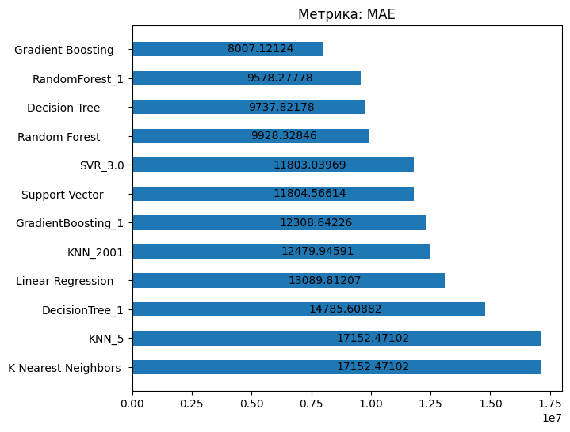

```python
metric_logger.plot('Метрика: ' + 'MAE', 'MAE', ascending=False, figsize=(7, 6))
```

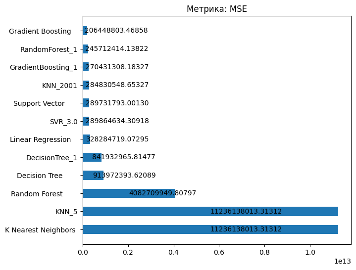

```python
metric_logger.plot('Метрика: ' + 'MSE', 'MSE', ascending=False, figsize=(7, 6))
```

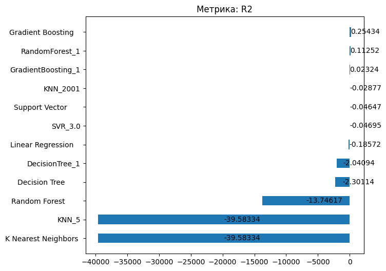

```python
metric_logger.plot('Метрика: ' + 'R2', 'R2', ascending=True, figsize=(7, 6))
```

**Вывод:** лучшими оказались модели на основе случайного леса и градиентного бустинга.